# Notebook of COVID-19 analyses

Daniel Ricard (daniel.ricard@gmail.com)

Last modified timestap: 2020-06-02 08:18:46 AST

# Context

Notes about analyses of COVID-19 data. Inspired by [an article on Towards Data Science](https://towardsdatascience.com/visualize-the-pandemic-with-r-covid-19-c3443de3b4e4). This document is an R markdown notebook available from my personal [viral2020 GitHub repository](https://github.com/ricardd/viral2020/).

# Worldwide cases and mortalities

Using information made available from the [European Centre for Disease Prevention and Control](https://www.ecdc.europa.eu/en/publications-data/download-todays-data-geographic-distribution-covid-19-cases-worldwide) and updated on a daily basis. There are likely other sources that are updated more regularly (e.g. the many sources used by [worldometers](https://www.worldometers.info/coronavirus/)), but this is a decent starting point.

Worldwide, there were 6,005,018 confirmed cases and 348,480 deaths as this document was generated using the data obtained from the ECDC (HTML document generated 2020-06-02 08:18:47 AST). A total of 208 countries had COVID-19 reported cases, 169 countries had more than 100 reported cases, and 71 countries had more than 100 reported deaths.

## Number of new deaths vs. cumulative deaths

Plot the number of new deaths or cases as a function of the cumulative number of deaths or cases and use a log scale on both axes. We do this for the number of deaths in the 10 countries with the most fatalities to date.

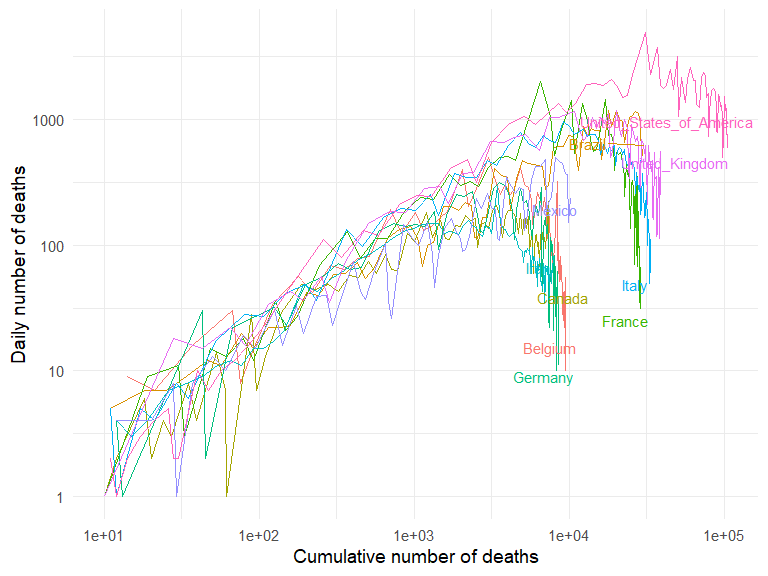

Let’s now do the same for another subset of countries.

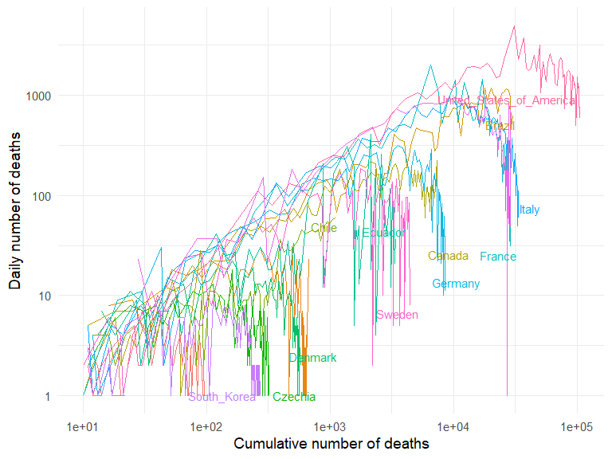

## Progression since 100 confirmed cases

Present the number of cumulative cases starting on the date when 100 or more cases were recorded in each country, and use a logarithmic scale for the y axis.

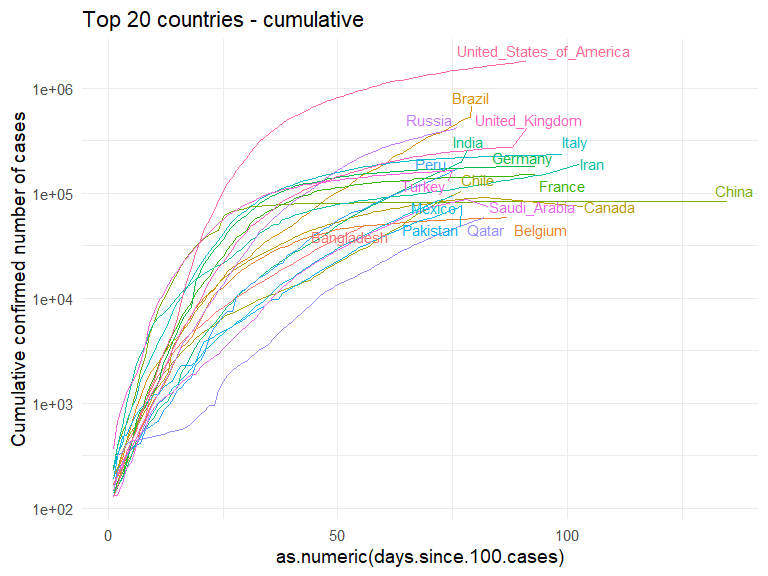

And do the same for the number of cumulative cases per one million people.

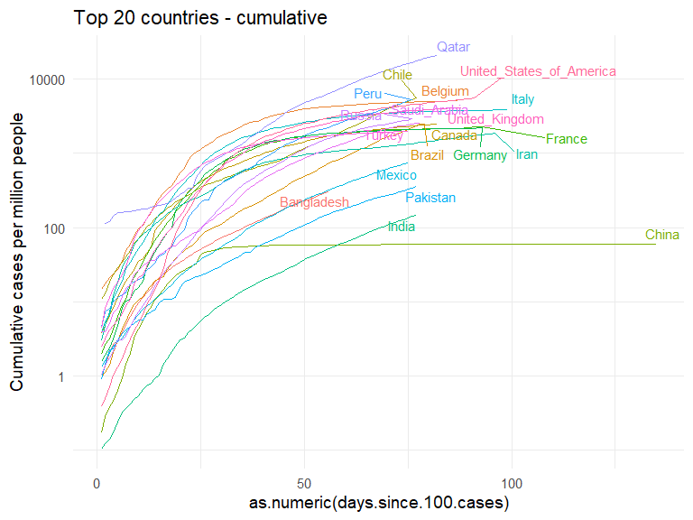

## Country-level summaries

How are different countries doing? I am testing a function that takes a country as an argument and fits both an exponential growth and a logistic growth model to the number of cumulative cases.

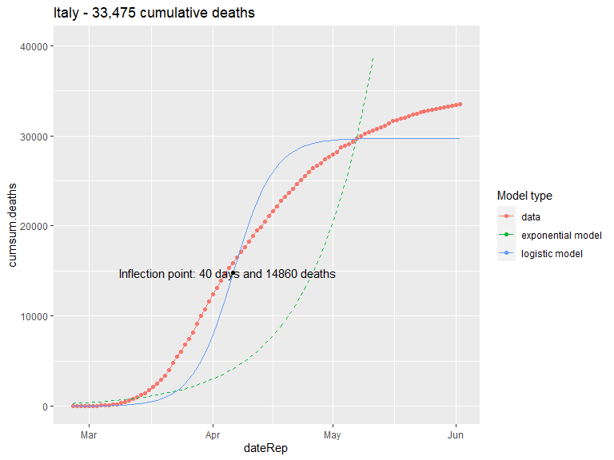

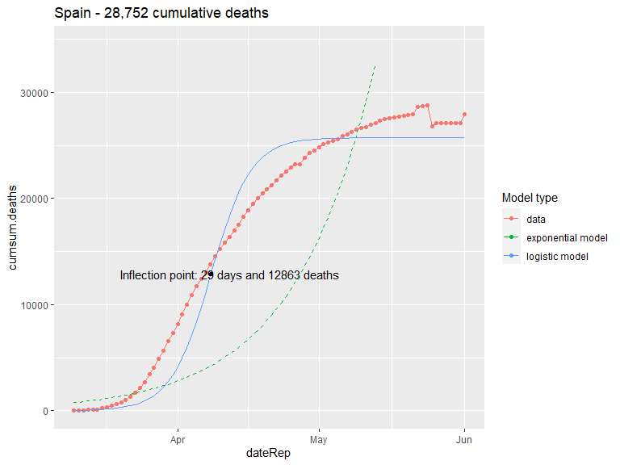

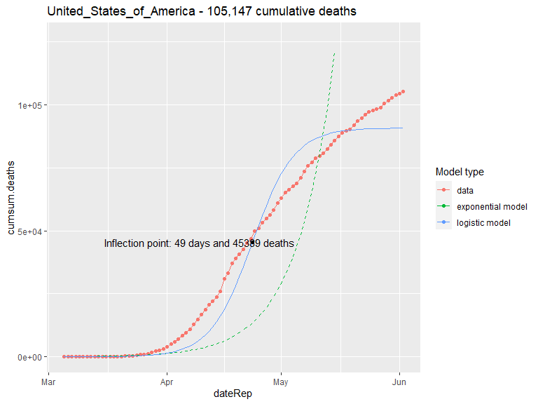

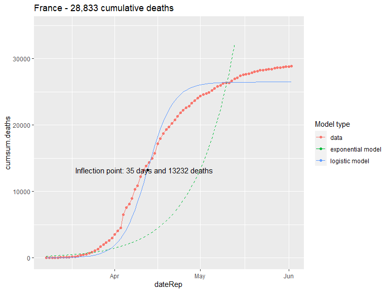

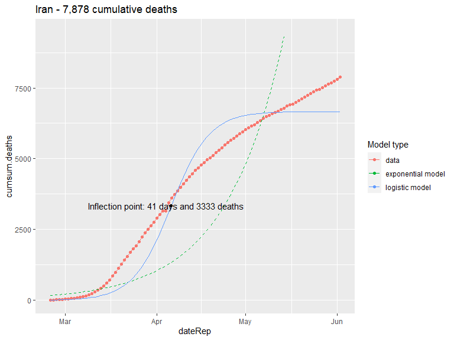

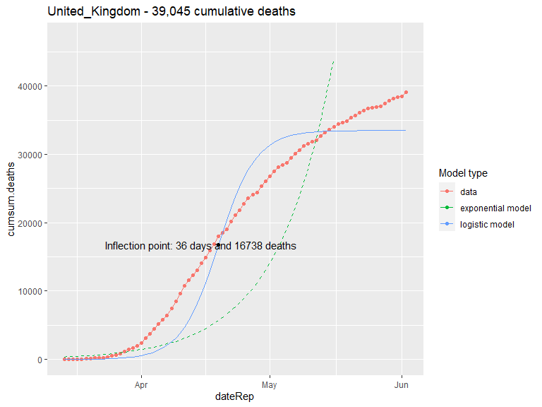

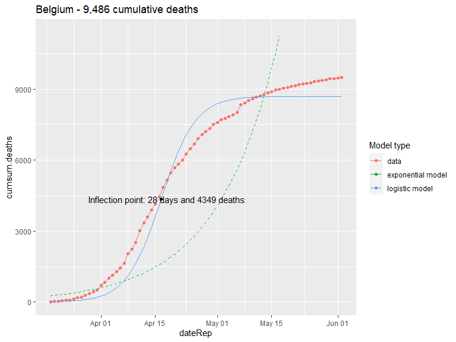

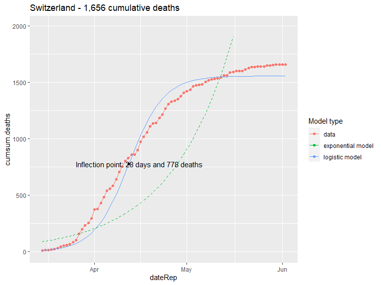

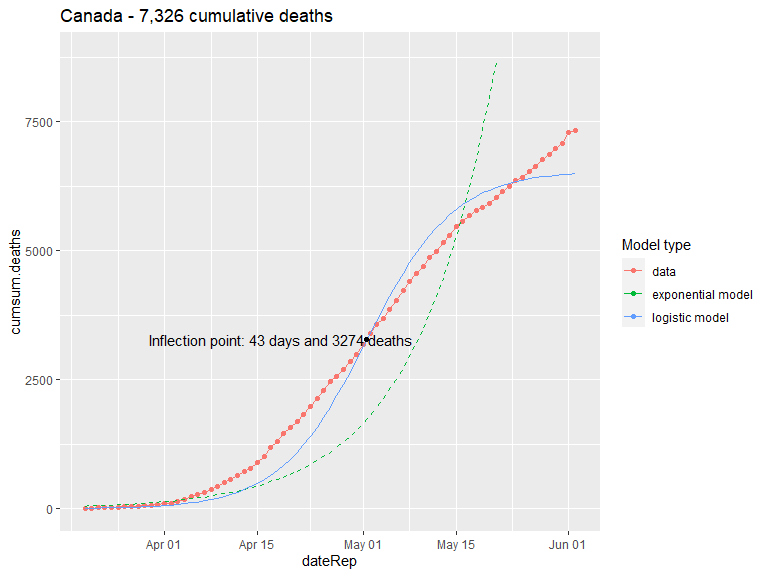

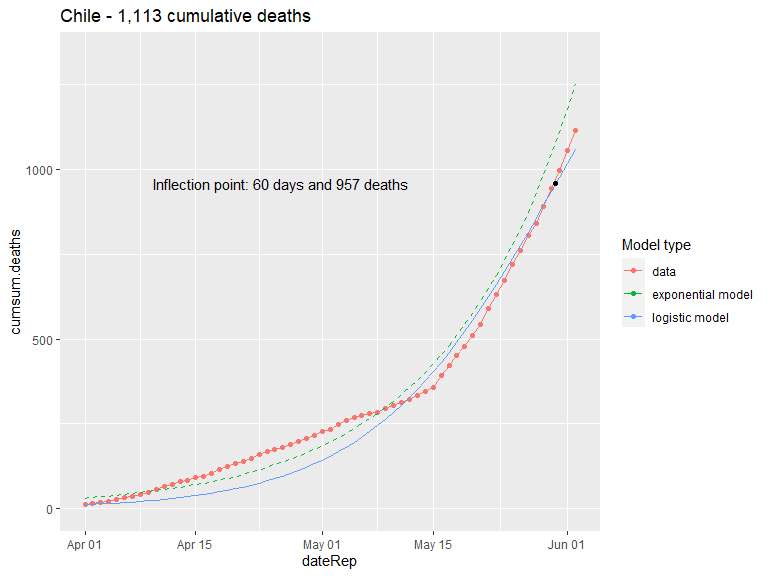

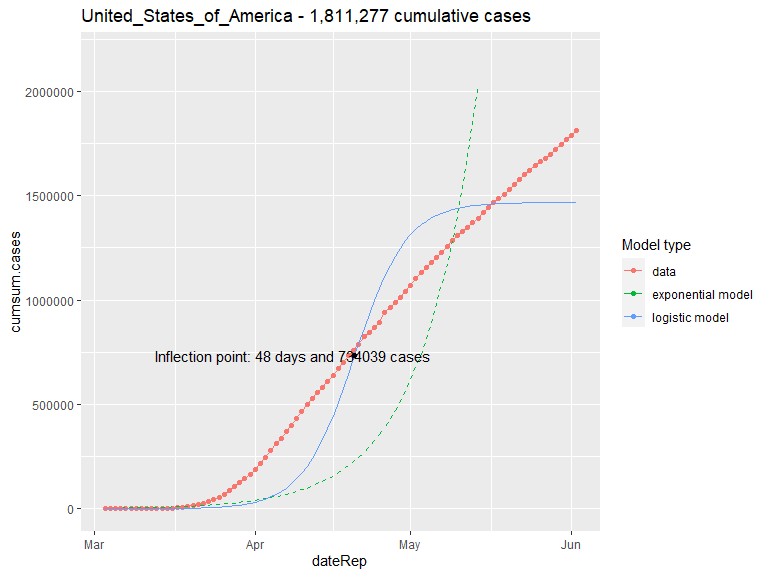

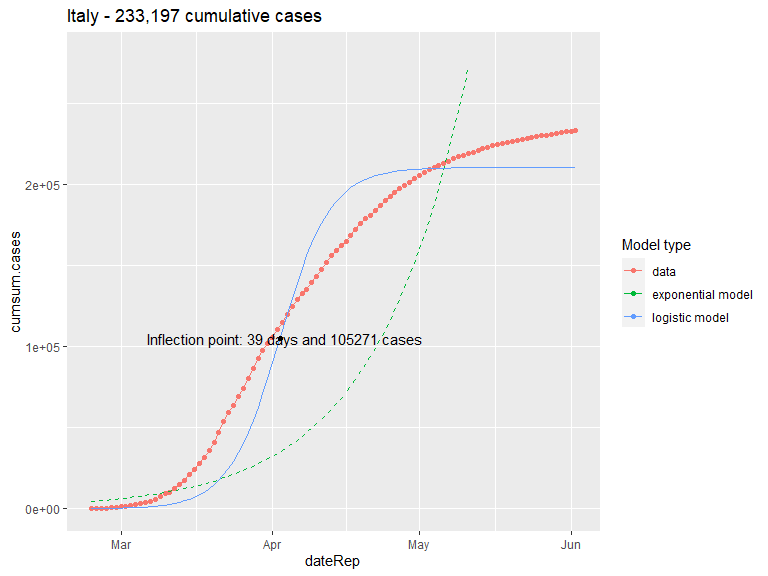

[19 more figures not shown]